# Incidents Responded to Across the City of Austin

## Author: Annie Fu (UT EID: arf2742)

### Introduction

Often, when 9-1-1 is dialed for a medical emergency, an ambulance will show up to help. But sometimes, the ambulances may get caught in traffic and may not be able to respond as quickly. Other times, ambulances from other counties and areas of the city may respond to a different area or county of the city, taking away resources from one area to aid other areas that don’t have enough of those particular resources. This led to the exploration of the differences in ambulance responses between the city of Austin and Travis County as well as whether or not ambulances responded quickly enough. After exploring the public database the local government provides (https://data.austintexas.gov/), the two datasets that were chosen to be analyzed were the EMS Ambulance Responses by Month (by regularly scheduled ambulances) and EMS Incident Responses by Month (any incidents that were responded to) in Austin, TX (sources cited at the end of this report, but the link to the ambulance dataset can be found [here](https://data.austintexas.gov/Public-Safety/EMS-Ambulance-Responses-by-Month/bptg-ndvw) and the link for the incident report can be found [here](https://data.austintexas.gov/Public-Safety/EMS-Incidents-by-Month/gjtj-jt2d)).

Each row for both datasets represent a singular month of a specific year (starting from 10/2010 to 1/2023), and they would be joined together by the Month.Key variable (which is formatted as YYYYMM), the Month.Year variable (formatted as MON YYYY), and the Location variable (listed as either `Austin` or `TC` after all of the data has been cleaned and tidied). Both datasets initially contain only numeric and date/time variables. The important variables that would need to be defined in the final dataset would be Incidents (the number of incidents that were responded to), Responses (the number incidents that were responded by regularly scheduled ambulance responses), Total_Responses (the total number of regularly scheduled responses), Compliance (the proportion in percent of responses that met or exceeded response time goals for that month of all the responses that were made), and Target.On.Time.Compliance (mutated later on in the visualization section of whether or not the compliance variable exceeded 90%). As a result, many different potential relationships can be explored: such as whether or not there is a change over time between location of the incidents that were responded to, whether there is a change in the regularly scheduled responses, whether priority has an effect on the compliance requirements, whether there are more incidents based on priority, etc.

Considering all of the potential relationships that can be explored, the following question was crafted: *How does the regularly scheduled ambulance responses differ between the city of Austin and Travis County in the month of November over the years?*

It’s predicted that there will be a significantly appearing difference between the mean scheduled ambulance responses of the city of Austin and Travis County in the month of November for all years with Austin having more ambulance responses than Travis County in the month of November over the years. In addition to this prediction, it is also predicted with other analysis that roughly 70% of all responses did meet the compliance goal of having 90% of all responses for a particular month in a particular year reach the emergency within the time response goal.

```r
# Call dplyr and ggplot2 packages within tidyverse
library(tidyverse)
library(tidytext)
library(textdata)

# Save the data as a dataframe
ambulance <- read.csv("ambulance.csv")
incidents <- read.csv("incidents.csv")
```

### 2. Tidying/Wrangling of Individual Datasets

The `ambulance` dataset contained around 21 columns, meaning that there were roughly 21 variables that the data collectors believed were important. After thorough examination of the data, it was found that 16 of the 21 columns could be condensed into 6 columns. These six columns would become the location the ambulance was deployed from, the destination that the ambulance was deployed to, the count of the number of ambulances that were deployed from location A to location B, the proportion in percent of ambulances from location A that were deployed to location B, the location that received regularly scheduled ambulances, and the total number of responses that particular location received. The first four columns were first tidied and then the last two columns were tidied separately.

However, before starting to condense the first four columns, it was necessary to rearrange the columns to have the response count values together and the percentage values together for easier tidying. Afterwards, the necessary columns that contained count values and the percent values of ambulances deployed from location A to bring assistance in location B were renamed in the following manner: `from/to/type`. This would later help in the `pivot_longer()` function to separate the variables.

```r
#reorder the columns of ambulance
ambulance <- ambulance[ , c(1, 2, 3, 4, 5, 6, 7, 8, 9, 12, 13, 14, 15, 10, 11, 16, 17, 18, 19, 20, 21)]

#rename the necessary columns for easier tidying later on
ambulance1 <- ambulance %>%
  rename("COA/COAorTC/Responses" = COA.Unit.Responses.into.COA.or.TC,
         "COA/TC/Responses" = COA.Unit.Responses.into.TC,
         "TC/COA/Responses" = TC.Unit.Responses.into.COA,
         "TC/COAorTC/Responses" = TC.Unit.Responses.into.COA.or.TC,
         "COA/Other/Responses" = Other.Area.Responses.by.COA.Units,
         "TC/Other/Responses" = Other.Area.Responses.by.TC.Units,
         "TC/COA/Percent" = Percent.COA.Responses.by.TC,
         "COA/Other/Percent" = Percent.of.Other.Area.Responses.by.COA.Units,
         "COA/TC/Percent" = Percent.TC.Responses.by.COA,
         "TC/Other/Percent" = Percent.of.Other.Area.Responses.by.TC.Units,
         "COA/COAorTC/Percent" = Percent.of.Responses.into.COA.or.TC.by.COA.Units,
         "TC/COAorTC/Percent" = Percent.of.Responses.into.COA.or.TC.by.TC.Units,
         "TC/TC/Percent" = Percent.of.TC.Responses.by.TC.Units,
         "COA/COA/Percent" = Percent.of.COA.Responses.by.COA.Units)

#ensure that data saved correctly
ambulance1
```

```
##   Month.Key Month.Year Total.System.Responses Total.Austin.Responses
## 1    201010   Oct 2010                   8773                   7424
## 2    201011   Nov 2010                   7693                   6421
## 3    201012   Dec 2010                   8065                   6737
## 4    201101   Jan 2011                   8158                   6946
##   Total.Travis.County.Responses Other.Area.Responses
## 1                          1333                   16
## 2                          1246                   26
## 3                          1295                   33
## 4                          1193                   19
##   Combined.City.and.County.Responses COA/TC/Responses TC/COA/Responses
## 1                               8757              648              268
## 2                               7667              579              196
## 3                               8032              584              206
## 4                               8139              560              228
```

[output cut: 21 more lines]

From there, `mutate()` was used to remove the destinations where there was ambiguity of where the ambulances went to (i.e. the destinations that contained the word `or` in them like `COA/COAorTC/Responses`). In the `mutate()` function, the counts were subtracted to obtain concrete values of how many ambulances went to where (i.e. transforming `COA/COAorTC/Responses` to `COA/COA/Responses` by subtracting the number of ambulances form COA to TC from COA to COA or TC). `select()` was used to remove the ambiguous and unnecessary columns and `pivot_longer()` was used to combine all of the columns with the name formatted as `from/to/type` into one column and their values in a separate column.

```r
#mutate the data to remove ambiguity and condense columns into one
ambulance1 <- ambulance1 %>%
  #remove the "or" destinations and have one single destination possible
  mutate("COA/COA/Responses" = `COA/COAorTC/Responses` - `COA/TC/Responses`,
         "TC/TC/Responses" = `TC/COAorTC/Responses` - `TC/COA/Responses`) %>%
  select(-c("COA/COAorTC/Responses", "TC/COAorTC/Responses", "COA/COAorTC/Percent", "TC/COAorTC/Percent", "Other.Area.Responses")) %>%

  #create a column of ambulances from location A to answer calls in Location B and type (% or count)
  pivot_longer(cols = c("COA/TC/Responses":"TC/TC/Responses"),
               names_to = "from.dest.type",
               values_to = "Count")


#ensure that data saved correctly
ambulance1
```

```
## # A tibble: 1,776 × 8
##    Month.Key Month.Year Total.System.Re…¹ Total…² Total…³ Combi…⁴ from.…⁵  Count
##        <int> <chr>                  <int>   <int>   <int>   <int> <chr>    <dbl>
##  1    201010 Oct 2010                8773    7424    1333    8757 COA/TC… 648
##  2    201010 Oct 2010                8773    7424    1333    8757 TC/COA… 268
##  3    201010 Oct 2010                8773    7424    1333    8757 COA/Ot…  15
##  4    201010 Oct 2010                8773    7424    1333    8757 TC/Oth…   1
##  5    201010 Oct 2010                8773    7424    1333    8757 TC/COA…   3.61
##  6    201010 Oct 2010                8773    7424    1333    8757 COA/TC…  48.6
##  7    201010 Oct 2010                8773    7424    1333    8757 COA/CO…  96.4
##  8    201010 Oct 2010                8773    7424    1333    8757 TC/TC/…  51.4
##  9    201010 Oct 2010                8773    7424    1333    8757 COA/Ot…  93.8
## 10    201010 Oct 2010                8773    7424    1333    8757 TC/Oth…   6.25
## # … with 1,766 more rows, and abbreviated variable names
## #   ¹Total.System.Responses, ²Total.Austin.Responses,
## #   ³Total.Travis.County.Responses, ⁴Combined.City.and.County.Responses,
## #   ⁵from.dest.type
```

The `separate()` function was then used to separate out the individual variables of `From` (the location where the ambulance was deployed from), `To` (the destination of the deployed ambulance), and `Type` (to indicate whether the value was the count of response or the proportion in percent of responses from location A that went to destination B). `pivot_wider()` was used to expand the `Type` column into their respective variables of `Responses` (count of ambulances) and `Percent` (proportion in percent of ambulances from location A that went to destination B).

```r
#create new column variables of from, to, and type and then to expand by type
ambulance1 <- ambulance1 %>%
  #separate the location of ambulance, location of incident, and type (percent or count)
  separate(from.dest.type,
           into = c("From", "To", "Type"),
           convert = TRUE, sep = "/") %>%

  #separate percentage and actual count of ambulance responses into different columns
  pivot_wider(names_from = Type,
              values_from = Count)

#ensure that data saved correctly
ambulance1
```

```
## # A tibble: 888 × 10
##    Month.Key Month…¹ Total…² Total…³ Total…⁴ Combi…⁵ From  To    Respo…⁶ Percent
##        <int> <chr>     <int>   <int>   <int>   <int> <chr> <chr>   <dbl>   <dbl>
##  1    201010 Oct 20…    8773    7424    1333    8757 COA   TC        648   48.6
##  2    201010 Oct 20…    8773    7424    1333    8757 TC    COA       268    3.61
##  3    201010 Oct 20…    8773    7424    1333    8757 COA   Other      15   93.8
##  4    201010 Oct 20…    8773    7424    1333    8757 TC    Other       1    6.25
##  5    201010 Oct 20…    8773    7424    1333    8757 COA   COA      7156   96.4
##  6    201010 Oct 20…    8773    7424    1333    8757 TC    TC        685   51.4
##  7    201011 Nov 20…    7693    6421    1246    7667 COA   TC        579   46.5
##  8    201011 Nov 20…    7693    6421    1246    7667 TC    COA       196    3.05
##  9    201011 Nov 20…    7693    6421    1246    7667 COA   Other      22   84.6
## 10    201011 Nov 20…    7693    6421    1246    7667 TC    Other       4   15.4
## # … with 878 more rows, and abbreviated variable names ¹Month.Year,
## #   ²Total.System.Responses, ³Total.Austin.Responses,
## #   ⁴Total.Travis.County.Responses, ⁵Combined.City.and.County.Responses,
## #   ⁶Responses
```

For the last two columns, the necessary columns had to first be renamed into the format of `Location/Total_Responses`. `pivot_longer()` was used to then make the necessary columns into one column labeled `Location/Total_Responses` which was then separated using the `separate()` function into the `Location` and the `Total_Responses` of the locations. However, since the `Count` variable contained the actual count of responses of each location per month, the `Total_Responses` column had to be selectively removed and the `Count` column from the `pivot_longer()` function was renamed to `Total_Responses` to create the final tidied dataset of `ambulance` (named `ambulance1`).

```r
#arrange the total responses by location
ambulance1 <- ambulance1 %>%
  #rename columns for easier tidying
  rename("Austin/Total_Responses" = Total.Austin.Responses,
         "TC/Total_Responses" = Total.Travis.County.Responses) %>%

  #make create the total responses of each area as its own column
  pivot_longer(cols = c("Austin/Total_Responses", "TC/Total_Responses"),
               names_to = "Location.Total_Responses",
               values_to = "Count") %>%

  #separate out the total responses from the location
  separate(Location.Total_Responses,
           into = c("Location", "Total_Responses"),
           convert = TRUE, sep = "/") %>%

  #remove column that says "total_response" and rename "Count" column into "Total_Response)
  select(-Total_Responses) %>%
  rename("Total_Responses" = Count)

#ensure that data saved correctly
ambulance1
```

```
## # A tibble: 1,776 × 10
##    Month.Key Month…¹ Total…² Combi…³ From  To    Respo…⁴ Percent Locat…⁵ Total…⁶
##        <int> <chr>     <int>   <int> <chr> <chr>   <dbl>   <dbl> <chr>     <int>
##  1    201010 Oct 20…    8773    8757 COA   TC        648   48.6  Austin     7424
##  2    201010 Oct 20…    8773    8757 COA   TC        648   48.6  TC         1333
##  3    201010 Oct 20…    8773    8757 TC    COA       268    3.61 Austin     7424
##  4    201010 Oct 20…    8773    8757 TC    COA       268    3.61 TC         1333
##  5    201010 Oct 20…    8773    8757 COA   Other      15   93.8  Austin     7424
##  6    201010 Oct 20…    8773    8757 COA   Other      15   93.8  TC         1333
##  7    201010 Oct 20…    8773    8757 TC    Other       1    6.25 Austin     7424
##  8    201010 Oct 20…    8773    8757 TC    Other       1    6.25 TC         1333
##  9    201010 Oct 20…    8773    8757 COA   COA      7156   96.4  Austin     7424
## 10    201010 Oct 20…    8773    8757 COA   COA      7156   96.4  TC         1333
## # … with 1,766 more rows, and abbreviated variable names ¹Month.Year,
## #   ²Total.System.Responses, ³Combined.City.and.County.Responses, ⁴Responses,
## #   ⁵Location, ⁶Total_Responses
```

The process to tidying the `incidents` dataset is almost identical to how the `ambulance` dataset was tidied. First, renaming had to be done to name the necessary columns into the following format: `location.priority.type`.

```r
#rename all of the columns that would need to be renamed
incidents1 <- incidents %>%
  rename("TC.P1.Incidents" = Travis.County.P1.Incidents,
         "TC.P2.Incidents" = Travis.County.P2.Incidents,
         "TC.P3.Incidents" = Travis.County.P3.Incidents,
         "TC.P4.Incidents" = Travis.County.P4.Incidents,
         "TC.P5.Incidents" = Travis.County.P5.Incidents,
         "Austin.P1.Compliance" = Austin.P1.On.Time.Compliance,
         "Austin.P2.Compliance" = Austin.P2.On.Time.Compliance,
         "Austin.P3.Compliance" = Austin.P3.On.Time.Compliance,
         "Austin.P4.Compliance" = Austin.P4.On.Time.Compliance,
         "Austin.P5.Compliance" = Austin.P5.On.Time.Compliance,
         "TC.P1.Compliance" = Travis.County.P1.On.Time.Compliance,
         "TC.P2.Compliance" = Travis.County.P2.On.Time.Compliance,
         "TC.P3.Compliance" = Travis.County.P3.On.Time.Compliance,
         "TC.P4.Compliance" = Travis.County.P4.On.Time.Compliance,
         "TC.P5.Compliance" = Travis.County.P5.On.Time.Compliance)

#double check that data is correctly tidied
incidents1
```

```
##   Month.Key Month.Year Total.Incidents Austin.Incidents Travis.County.Incidents
## 1    201010   Oct 2010            8910             7571                    1321
## 2    201011   Nov 2010            7826             6564                    1232
## 3    201012   Dec 2010            8182             6858                    1290
##   Other.Area.Incidents Combined.Austin.and.Travis.County.Incidents
## 1                   18                                        8892
## 2                   30                                        7796
## 3                   34                                        8148
##   Austin.P1.Incidents Austin.P2.Incidents Austin.P3.Incidents
## 1                 533                2103                1039
## 2                 401                1896                 931
## 3                 458                1892                 903
##   Austin.P4.Incidents Austin.P5.Incidents TC.P1.Incidents TC.P2.Incidents
## 1                2938                 958              81             380
## 2                2540                 796              83             346
```

[output cut: 22 more lines]

Afterwords, the `pivot_longer()` was used to organize all of the columns formatted as `location.priority.type` into one column with their values as a separate column. `separate()` was then used to separate out the `location.priority.type` column into their separate columns of `Location` (the location of where the incidents were), `Priority` (the priority level of the incidents, and `Type` (whether it was the count of incidents or whether it was the percent of responses that met the time response goals).

```r
#condense columns into one
incidents1 <- incidents1 %>%
  #create a column that has location, priority, and type as one column with values
  pivot_longer(cols = c("Austin.P1.Incidents":"TC.P5.Incidents", "Austin.P1.Compliance":"TC.P5.Compliance"),
               names_to = "location.priority.type",
               values_to = "Count") %>%

  #separate out the location, priority and type columns
  separate(location.priority.type,
           into = c("Location", "Priority", "Type"),
           convert = TRUE)

#double check that data is correctly tidied
incidents1
```

```
## # A tibble: 2,960 × 15
##    Month.Key Month.Year Total.…¹ Austi…² Travi…³ Other…⁴ Combi…⁵ Overa…⁶ Austi…⁷
##        <int> <chr>         <int>   <int>   <int>   <int>   <int>   <dbl>   <dbl>
##  1    201010 Oct 2010       8910    7571    1321      18    8892    95.8    97.3
##  2    201010 Oct 2010       8910    7571    1321      18    8892    95.8    97.3
##  3    201010 Oct 2010       8910    7571    1321      18    8892    95.8    97.3
##  4    201010 Oct 2010       8910    7571    1321      18    8892    95.8    97.3
##  5    201010 Oct 2010       8910    7571    1321      18    8892    95.8    97.3
##  6    201010 Oct 2010       8910    7571    1321      18    8892    95.8    97.3
##  7    201010 Oct 2010       8910    7571    1321      18    8892    95.8    97.3
##  8    201010 Oct 2010       8910    7571    1321      18    8892    95.8    97.3
##  9    201010 Oct 2010       8910    7571    1321      18    8892    95.8    97.3
## 10    201010 Oct 2010       8910    7571    1321      18    8892    95.8    97.3
## # … with 2,950 more rows, 6 more variables:
## #   Travis.County.On.Time.Compliance <dbl>, Target.On.Time.Compliance <int>,
## #   Location <chr>, Priority <chr>, Type <chr>, Count <dbl>, and abbreviated
## #   variable names ¹Total.Incidents, ²Austin.Incidents,
## #   ³Travis.County.Incidents, ⁴Other.Area.Incidents,
## #   ⁵Combined.Austin.and.Travis.County.Incidents, ⁶Overall.On.Time.Compliance,
## #   ⁷Austin.On.Time.Compliance
```

To have `Incidents` (the count of incidents that were responded to for a particular priority level in a location) and `Compliance` (the percent of incidents where the response time met or exceeded the goal) into separate columns, the `pivot_wider` column was used to create the final tidy dataset of `incidents` (named `incidents1`.

```r
#make incidents and compliance into separate variables
incidents1 <- incidents1 %>%
  pivot_wider(names_from = Type,
              values_from = Count)

#double check that data is correctly tidied
incidents1
```

```
## # A tibble: 1,480 × 15
##    Month.Key Month.Year Total.…¹ Austi…² Travi…³ Other…⁴ Combi…⁵ Overa…⁶ Austi…⁷
##        <int> <chr>         <int>   <int>   <int>   <int>   <int>   <dbl>   <dbl>
##  1    201010 Oct 2010       8910    7571    1321      18    8892    95.8    97.3
##  2    201010 Oct 2010       8910    7571    1321      18    8892    95.8    97.3
##  3    201010 Oct 2010       8910    7571    1321      18    8892    95.8    97.3
##  4    201010 Oct 2010       8910    7571    1321      18    8892    95.8    97.3
##  5    201010 Oct 2010       8910    7571    1321      18    8892    95.8    97.3
##  6    201010 Oct 2010       8910    7571    1321      18    8892    95.8    97.3
##  7    201010 Oct 2010       8910    7571    1321      18    8892    95.8    97.3
##  8    201010 Oct 2010       8910    7571    1321      18    8892    95.8    97.3
##  9    201010 Oct 2010       8910    7571    1321      18    8892    95.8    97.3
## 10    201010 Oct 2010       8910    7571    1321      18    8892    95.8    97.3
## # … with 1,470 more rows, 6 more variables:
## #   Travis.County.On.Time.Compliance <dbl>, Target.On.Time.Compliance <int>,
## #   Location <chr>, Priority <chr>, Incidents <dbl>, Compliance <dbl>, and
## #   abbreviated variable names ¹Total.Incidents, ²Austin.Incidents,
## #   ³Travis.County.Incidents, ⁴Other.Area.Incidents,
## #   ⁵Combined.Austin.and.Travis.County.Incidents, ⁶Overall.On.Time.Compliance,
## #   ⁷Austin.On.Time.Compliance
```

### 3. Joining/Merging

The two datasets were joined by the `Month.Key`, `Month.Year` and `Location` variables to create the final dataset of `austin_ems`.

```r
#join data together and save as austin_ems
austin_ems <- left_join(ambulance1, incidents1, by = c("Month.Key", "Month.Year", "Location"))

#double check data is correctly joined
austin_ems
```

```
## # A tibble: 8,880 × 22
##    Month.Key Month…¹ Total…² Combi…³ From  To    Respo…⁴ Percent Locat…⁵ Total…⁶
##        <int> <chr>     <int>   <int> <chr> <chr>   <dbl>   <dbl> <chr>     <int>
##  1    201010 Oct 20…    8773    8757 COA   TC        648    48.6 Austin     7424
##  2    201010 Oct 20…    8773    8757 COA   TC        648    48.6 Austin     7424
##  3    201010 Oct 20…    8773    8757 COA   TC        648    48.6 Austin     7424
##  4    201010 Oct 20…    8773    8757 COA   TC        648    48.6 Austin     7424
##  5    201010 Oct 20…    8773    8757 COA   TC        648    48.6 Austin     7424
##  6    201010 Oct 20…    8773    8757 COA   TC        648    48.6 TC         1333
##  7    201010 Oct 20…    8773    8757 COA   TC        648    48.6 TC         1333
##  8    201010 Oct 20…    8773    8757 COA   TC        648    48.6 TC         1333
##  9    201010 Oct 20…    8773    8757 COA   TC        648    48.6 TC         1333
## 10    201010 Oct 20…    8773    8757 COA   TC        648    48.6 TC         1333
## # … with 8,870 more rows, 12 more variables: Total.Incidents <int>,
## #   Austin.Incidents <int>, Travis.County.Incidents <int>,
## #   Other.Area.Incidents <int>,
## #   Combined.Austin.and.Travis.County.Incidents <int>,
## #   Overall.On.Time.Compliance <dbl>, Austin.On.Time.Compliance <dbl>,
## #   Travis.County.On.Time.Compliance <dbl>, Target.On.Time.Compliance <int>,
## #   Priority <chr>, Incidents <dbl>, Compliance <dbl>, and abbreviated …
```

After joining the two datasets together, it is found that there are 8880 observations— 8,732 more observations that were added compared to the original datasets. This could be a problem as there are now roughly 60 different observations for one month in a year (i.e. 60 different values to look at for Oct 2010). If the variables aren’t defined properly, creating visualizations or wrangling the data may be difficult in the future since it could result in losing 60 observations by mistake compared to losing one observation.

### 4. Wrangling of Combined Data

To wrangle the data, 5/6 of the core `dplyr` functions were used: `arrange`, `mutate`, `group_by`, `filter`, and `summarise`. The last one (`select`) was used in the wrangling of the original datasets in section 2.

`separate` was used to separate the `Month.Year` variable into `Month` and `Year`, `na.omit()` was used to remove any `NA` values if there were any and `arrange` was used to arrange the data by `Location`, `Month.Key`, then `From` to organize the data by the locations where the ambulances were deployed from in a particular month of a year of a particular location.

```r
#wrangle and organize combined data (separate month and year, remove all NA values, and arrange data by location, time, and from)
austin_ems <- austin_ems %>%
  separate(Month.Year, into = c("Month", "Year"), convert = TRUE) %>%
  na.omit() %>%
  arrange(Location, Month.Key, From)
```

`mutate` was used to make a numerical variable into a categorical variable by checking the `Compliance` column (if above 90, then it was labeled as `Met`; otherwise, it was labeled as `Not Met`). `group_by` was used to organize the data by the location, `filter` only took the data in November, and `summarise` found the mean, standard deviation, counts, and proportions of the respective numerical variables `Incidents` and `Total_Responses` and the newly mutated categorical variable `Target.On.Time.Compliance`.

```r
#check summary statistics of incidents, responses, and compliance between Austin and Travis County
austin_ems %>%
  #create categorical variable of whether or not compliance was met (> 90 was met)
  mutate(Target.On.Time.Compliance = ifelse(Compliance > 90, "Met", "Not Met")) %>%

  #organize summary statistics by location
  group_by(Location) %>%

  #filter for only novemeber values
  filter(Month == "Nov") %>%

  #find summary statistics of incidents, responses, and compliance in Austin
  summarise(mean_incidents = mean(Incidents), sd_incidents = sd(Incidents),
            mean_responses = mean(Total_Responses), sd_Responses = sd(Total_Responses),
            count_met_compliance = sum(Target.On.Time.Compliance == "Met"),
            prop_met_compliance = sum(Target.On.Time.Compliance == "Met") / (sum(Target.On.Time.Compliance == "Met") +  sum(Target.On.Time.Compliance == "Not Met")))
```

```
## # A tibble: 2 × 7
##   Location mean_incidents sd_incidents mean_responses sd_Respo…¹ count…² prop_…³
##   <chr>             <dbl>        <dbl>          <dbl>      <dbl>   <int>   <dbl>
## 1 Austin            1658.         868.          8311.       829.     348   0.892
## 2 TC                 267.         155.          1326.       200.     192   0.492
## # … with abbreviated variable names ¹sd_Responses, ²count_met_compliance,
## #   ³prop_met_compliance
```

For the city of Austin, the mean number of incidents responded to in the month of November over all years was around 1657.6462 incidents with a standard deviation of 868.2941 incidents, meaning that the spread of incidents that were responded to wasn’t too large but wasn’t quite small. The mean number of incidents responded by regularly scheduled ambulances in the month of November over all years was 8310.769 responses with a standard deviation of 828.8706 responses, meaning that the spread of responses by regularly scheduled ambulances was quite small. The number of responses that met the response time goal (compliance) in the month of November over all years was around 348 which meant that roughly 0.8923077 of all incidents in the month of November over all years were responded in the response time goal.

As for Travis County, the mean number of incidents in the month of November over all years was around 267.1231 incidents with a standard deviation of 154.6205, meaning that the spread of incidents that were responded to was large. The mean number of incidents responded by regularly scheduled ambulances in the month of November over all years was 1326.308 responses and has the standard deviation of 199.8496, meaning that the spread of the responses by regularly scheduled ambulances in the month of November over all years was small. The number of responses that met the response time goal in the month of November over all years was 192, meaning that roughly 0.4923077 of all incidents in the month of November over all years were responded in the response time goal.

### 5. Visualizing

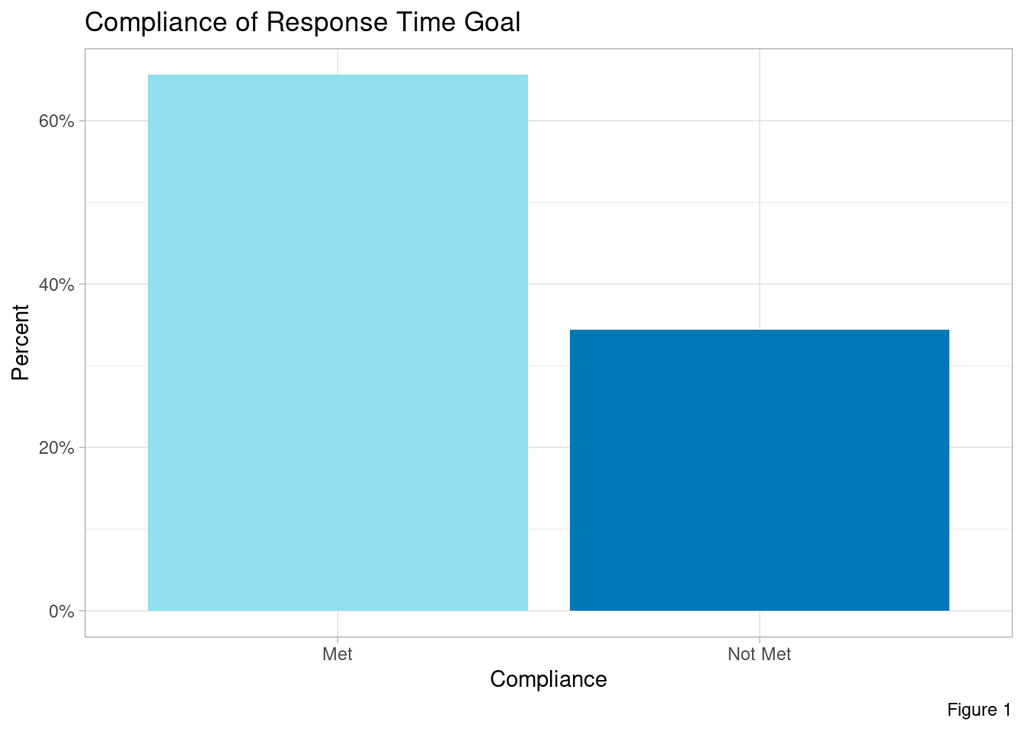

```r
#visualization of whether or not response time goal was met (compliance)
austin_ems %>%
  #mutates column to become categorical variable of whether or not compliance was met
  mutate(Target.On.Time.Compliance = ifelse(Compliance > 90, "Met", "Not Met")) %>%

  #creates bar graph comparing whether compliance was met or not
  ggplot(aes(x = Target.On.Time.Compliance, fill = Target.On.Time.Compliance)) +
  geom_bar(aes(y = after_stat(count/sum(count)))) +
  scale_y_continuous(labels = scales::percent) +
  scale_fill_manual(values = c("#90e0ef", "#0077b6")) +
  labs(title = "Compliance of Response Time Goal",
       caption = "Figure 1",
       x = "Compliance",
       y = "Percent") +
  theme_light() +
  theme(legend.position = "none")
```

This graph depicts the percentage of all responses to incidents that either met or or didn’t meet the compliance response goal time (90% of all calls met the response time goal). Based on the graph, it seems that roughly 65% of all responses met the compliance goal of 90% while around 35% of all responses didn’t quite meet the compliance goal. This means that there were still ambulances, despite being regularly scheduled, that didn’t respond quickly enough to an emergency. This may be due to traffic in the area which delays the time it takes for an ambulance to arrive.

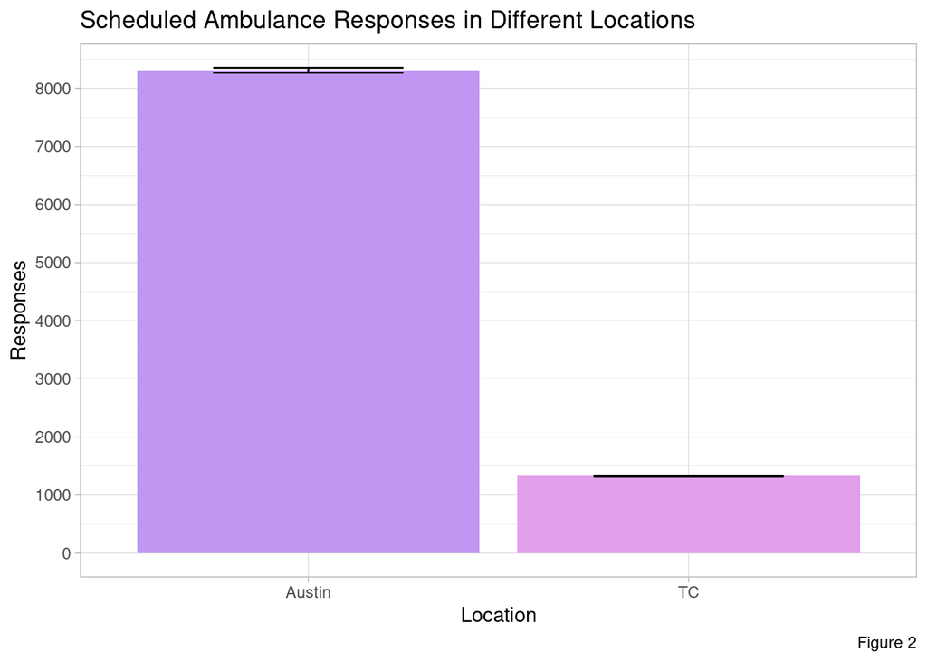

```r
#visualization to compare the number of incidents that were responded to different locations
austin_ems %>%
  filter(Month == "Nov") %>%
  ggplot(aes(x = Location, y = Total_Responses, fill = Location)) +
  geom_bar(stat = "summary", fun = "mean") +
  geom_errorbar(stat = "summary", fun.data = "mean_se", width = 0.5) +
  scale_fill_manual(values = c("#bf96f2", "#e29fe9")) +
  scale_y_continuous(breaks = seq(0, 9000, 1000)) +
  labs(title = "Scheduled Ambulance Responses in Different Locations",
       caption = "Figure 2",
       x = "Location",
       y = "Responses") +
  theme_light() +
  theme(legend.position = "none")
```

This graph describes the difference in mean total responses that were responded to by scheduled ambulances between the City of Austin and Travis County. Based on the graph, the city of Austin has a significantly different mean total responses from scheduled ambulances compared to Travis County as the value of the Austin bar is much higher than the value of the Travis County bar, with their standard error bars having no overlap. This may be because the population in the city of Austin is far greater than the population in Travis County, so there aren’t as many emergencies that arise thus there are less scheduled ambulances for Travis County than the city of Austin to be deployed for emergencies.

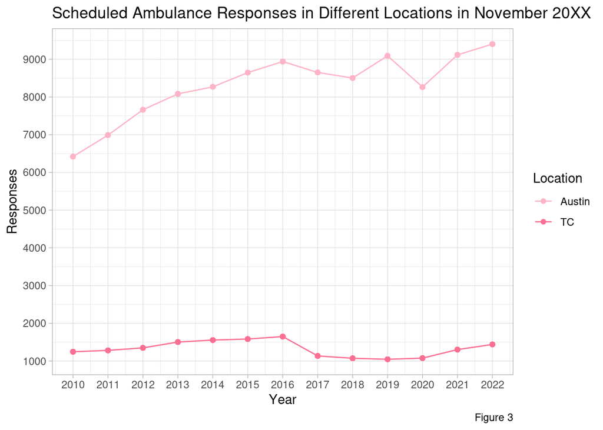

```r
#visualization of average scheduled ambulance responses for different locations in November over the years years
austin_ems %>%
  filter(Month == "Nov") %>%
  ggplot(aes(x = Year, y = Total_Responses, color = Location)) +
  geom_point() +
  geom_line() +
  scale_color_manual(values = c("#ffb3c6", "#fb6f92")) +
  scale_x_continuous(breaks = seq(2010, 2022, 1)) +
  scale_y_continuous(breaks = seq(0, 9000, 1000)) +
  theme_light() +
  labs(title = "Scheduled Ambulance Responses in Different Locations in November 20XX",
       caption = "Figure 3",
       x = "Year",
       y = "Responses",
       color = "Location")
```

This graph describes the overall trend of the regularly scheduled response amounts of the city of Austin and Travis County in November over the years. First, it’s observed that there is a large difference between the number of responses in the city of Austin and Travis County with the city of Austin having more regularly responses every year. For the city of Austin, there seems to be a positive correlation between the years and the amount of responses in the month of November (as the years increase, the number of regularly scheduled responses seem to also increase). On the other hand, Travis County seemed to have a very weak positive correlation between years and responses until 2016 where a larger but still weak negative correlation seems to occur before returning back to a weak positive correlation in 2020. Considering the issues happening in the world, it may be that COVID-19 might have had an effect on the number of regularly scheduled ambulance responses as the virus spread rapidly around the US from 2020 onwards.

### 6. Discussion

There is a significant difference between the city of Austin and Travis County in their regularly scheduled ambulance responses for the month of November over the years. Looking at Figure 3, there seems to be no overlap between the lines of the regularly scheduled responses, and Figure 2 further proves that they have a large mean difference in regularly scheduled responses as the mean bars are significantly different with no overlap in the standard error bars. When looking at the overall statistics, the mean scheduled responses that occurred in the city of Austin within the month of November over all years was 8310.769 which was roughly 7000 more mean responses than Travis County (around 1326.308 regularly scheduled ambulance responses), both with small standard deviations. However, this may be due to a confounding variable of population size in the city of Austin and Travis County as they may have very different populations with the city of Austin having more people and Travis County having far less. To explore the data further to prove this, it may be better to find a dataset that contains the population of the city of Austin and Travis County over time and measure the ratio of ambulance responses to population and see if there truly is a difference in their regularly scheduled ambulance responses for their respective populations.

Conducting this project was not as easy as it seemed initially. The hardest part was figuring out how to wrangle and tidy the data since it wasn’t as crystal clear as it usually is in lab or in class. From this process, I have learned just how much time it takes to organize the data into what I am looking for compared to creating the visualizations since it took me roughly a week to finalize my final dataset compared to the few hours it took me to create three different visualizations. Furthermore, I learned just how difficult it is to pose a particular question for research with data as the research question slowly becomes created by the data rather than an initial idea that came from my mind.

Acknowledgments: The City of Austin’s Government for providing the datasets I used for this research project and Dr. Layla Guyot for answering questions that I had while conducting this project.

Sources:  
Ambulance Data: https://data.austintexas.gov/Public-Safety/EMS-Ambulance-Responses-by-Month/bptg-ndvw/  
Incidents Data: https://data.austintexas.gov/Public-Safety/EMS-Incidents-by-Month/gjtj-jt2d/

[output not shown]